# R ile Tanımlayıcı İstatistikler ve Hipotez Testleri

# 4 Normallik Testleri

İstatistiksel analizler çeşitli varsayımlara dayanmaktadır. Bu varsayımlardan bir tanesi de değişkenlerin normal dağılıma sahip olması varsayımıdır.

Çoğu zaman bu varsayım ihmal edilerek güvenilir olmayan sonuçlar ortaya çıkmaktadır.

İstatistiksel yöntemlerin birçoğunda yapılacak analizin türüne bağlı olarak veriler normal dağılıma sahip olmak zorundadır.

Ancak bu varsayımın her zaman sağlanamadığı ve çeşitli sebeplerle zaman zaman verilerin dağılımında normalden sapmaların ortaya çıktığı görülmektedir.

Dağılımın normal olup olmadığı üç farklı yaklaşımdan hareketle ortaya konulabilir. Bu yaklaşımlar;

- Çarpıklık ($\alpha_3$) ve basıklık ($\alpha_4$) ölçüleri
- Grafikler (Histogram, Q-Q, P-P, …)
- Hipotez testleri (Shapiro-Wilk, Kolmogorov-Smirnov, Anderson-Darling, …)

**http://biosoft.erciyes.edu.tr/app/MVN**

```r
# Ağırlığa ait çarpıklık ve basıklık ölçüleri

sekil_olcusu <- tmp %>%
  group_by(Grup) %>%
  summarise(N = n(), Çarpıklık = round(skewness(Ağırlık),2),
                     Basıklık = round(kurtosis(Ağırlık),2))
print.data.frame(sekil_olcusu)
```

```
##            Grup  N Çarpıklık Basıklık
## 1       Kontrol 20      0.63     3.51
## 2 Steatohepatit 20     -0.15     2.97
```

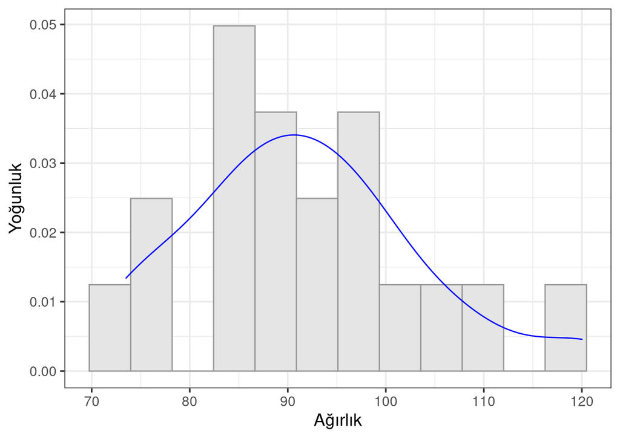

```r
# Ağırlığa ait histogram grafiği

tmp %>%
filter(Bki_grup==1)%>%     # 1: Obez olan
ggplot(aes(x = Ağırlık, y= ..density..))+
  geom_histogram(bins = 12, fill = "gray90", colour = "gray60")+
  geom_density(colour = "blue", linewidth = 2)+
  theme_bw(base_size = 14) +
    labs(y ="Yoğunluk", x = expression("Ağırlık"))
```

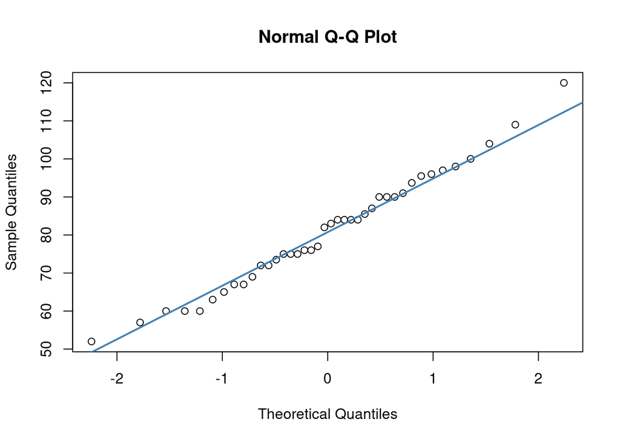

```r
# Ağırlığa ait Q-Q grafiği

qqnorm(tmp %$% Ağırlık, pch = 1, frame = T)
qqline(tmp %$% Ağırlık, col = "steelblue", lwd = 2)
```

```r
# Ağırlığa ait Shapiro-Wilk hipotez testi

# H0: Normal dağılıma uygunluk vardır.
# (Serinin dağılımı ile normal dağılım arasında istatistiksel bakımdan anlamlı bir fark yoktur.)

# H1: Normal dağılıma uygunluk yoktur.
# (Serinin dağılımı ile normal dağılım arasında istatistiksel bakımdan anlamlı bir fark vardır.)

tmp %>%
  filter(Bki_grup == 1) %$%    # 1: Obez olan
  shapiro.test(Ağırlık)
```

```
##
##  Shapiro-Wilk normality test
##
## data:  Ağırlık
## W = 0.96649, p-value = 0.7047
```

# 5 Hipotez Testleri

**Hipotez:** Doğruluğu bir araştırma ya da deney ile test edilmeye çalışılan öngörülere, iddialara, hükümlere denir.

**Hipotez testleri:** Elde edilen değerlerin ya da varılan sonuçların istatistiksel olarak anlamlı olup olmadığını (önem taşıyıp taşımadığını) test etmek için başvurulan yöntemdir. Hipotez testlerinde birbirinin zıddı hükümler içeren iki hipotez bulunmaktadır.

**Sıfır Hipotezi (Yokluk Hipotezi):**Benzerlik, eşitlik, bağımsızlık, ilişkisizlik gibi ifadeler kullanılmaktadır. $H_0$ sembolü ile gösterilmektedir. Örneklemden elde edilen sonuçların tesadüfe bağlı olduğunu ifade etmektedir.

- $H_0$:İdrar yolu enfeksiyonu olan ve olmayan gebelerin CRP düzeyleri birbirine eşittir.

**Karşıt Hipotez (Alternatif Hipotez):**Farklılığı, eşit olmayan durumu, bağımlılık gibi ifadeler kullanılmaktadır. $H_1$ sembolü ile gösterilmektedir. Örneklemden elde edilen sonuçların tesadüfe bağlı olmadığını ifade etmektedir.

- $H_1$:İdrar yolu enfeksiyonu olan ve olmayan gebelerin CRP düzeyleri birbirine eşit değildir.

Hipotez testleri sonucunda $H_0$ hipotezi **kabul** veya **red** edilir.

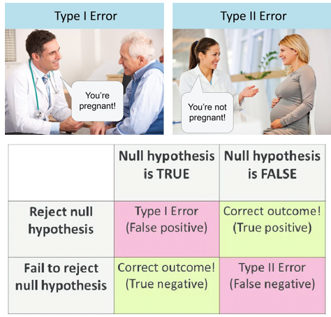

**İstatistiksel Karar**

Tüm testlerin sonunda, $H_0$ hipotezinin reddedilmesi halinde düşülecek gerçek hata miktarı(p değeri) belirlenir. Bu değer önceden belirlenmiş olan $\alpha$ değeri ile karşılaştırılır.

- $p$ < $\alpha$ ise $H_0$ hipotezi reddedilir. Bu karar, örneklemden elde edilen sonuçların istatistiksel açıdan önemli olduğu yani $H_1$ hipotezinin kabul edildiği anlamına gelir.
- $p$ > $\alpha$ ise $H_0$ hipotezi kabul edilir. Bu karar, örneklemden elde edilen sonuçların istatistiksel açıdan önemli olmadığı anlamına gelir.

**İstatistiksel Önemlilik Testinin Seçim Kriterleri**

- Kurulan hipotezde parametre kullanılıp kullanılmamasına,
- Parametre sayısına,
- Örnek(grup) sayısına,
- Örneklemin bağımlı olup olmadığına,
- Test edilecek değişken sayısına bağlı olarak farklı biçimlerde sınıflandırılır.

**Test edilen değişken sayısına göre**

- Tek değişkenli önemlilik testleri
- Çok değişkenli önemlilik testleri

**Kurulan hipotezin parametreye dayalı olup olmadığına göre**

- Parametrik önemlilik testleri
- Parametrik olmayan önemlilik testleri

**Örneklem sayısına göre**

- Tek örneklem testleri
- İki örneklem testleri
- k-örneklem testlerii

**Örneklemin bağımlı olup olmadığına göre**

1. **Bağımlı örneklem testleri**
- Bağımlı iki örneklem testleri
- Bağımlı k-örneklem testleri
2. **Bağımsız örneklem testleri**
- Bağımsız iki örneklem testleri
- Bağımsız k-örneklem testleri

**Hipotezin kuruluş biçimine göre**

- Ortalamaya dayalı testler
- Orana dayalı testler
- Gözlem sayılarına dayalı testler
- Dağılıma dayalı testler
- Sıralama puanlarına dayalı testler
- Uyuma, uygunluğa dayalı testler
- …

## 5.1 Tek örneklem t testi (One sample t test)

**Varsayımlar**

- Örneklem ilgili kitleden **rastgele** ve **tek örneklem** grubundan seçilmiş olmalıdır.
- İlgili değişken nicel olmalıdır.
- ilgili değişken normal dağılıma uymalıdır.
- Kitle ortalamasının belli bir değere eşit olup olmadığı test edilir.

**Örnek:** Obez olan grupta ALT düzeyinin ortalamasının 35’e eşit olup olmadığı araştırılmak istenmektedir. İlgili örnek için hipotez aşağıdaki gibidir.

$$\begin{align*}
H_0:&~ \mu_{ALT} = 35 \\
H_1:&~ \mu_{ALT} \neq 35
\end{align*}$$

```r
# Tek örneklem t testi

tmp %>%
  filter(Bki_grup == 1) %$%   # 1: Obez olan
  t.test(x = ALT, alternative = "two.sided", mu = 35, conf.level = .95)
```

```
##
##  One Sample t-test
##
## data:  ALT
## t = 3.144, df = 18, p-value = 0.005612
## alternative hypothesis: true mean is not equal to 35
## 95 percent confidence interval:
##  43.87027 79.60342
## sample estimates:
## mean of x
##  61.73684
```

## 5.2 İşaret testi (Sign test)

**Varsayımlar**

- Örneklem ilgili kitleden **rastgele** ve **tek örneklem grubundan** seçilmiş olmalıdır.
- İlgili değişken **nicel** olmalıdır.
- ilgili değişken normal dağılıma uymamalıdır.
- Kitle ortalamasının belli bir değere eşit olup olmadığı test edilir.

**Örnek:** Obez olan grupta Tg1 düzeyinin ortancasının 150’ye eşit olup olmadığı araştırılmak istenmektedir. İlgili örnek için hipotez aşağıdaki gibidir.

$$\begin{align*}
H_0:&~ \mu_{Tg1} = 150 \\
H_1:&~ \mu_{Tg1} \neq 150
\end{align*}$$

```r
# İşaret testi

tmp %>%
  filter( Bki_grup == 1) %$%   # 1: Obez olan
  wilcox.test(x = Tg1, alternative = "two.sided", mu = 150, conf.level = .95,
              correct = FALSE, exact = FALSE)
```

```
##
##  Wilcoxon signed rank test
##
## data:  Tg1
## V = 96, p-value = 0.9679
## alternative hypothesis: true location is not equal to 150
```

## 5.3 Bağımsız iki örneklem t testi (Independent two sample t test)

**Varsayımlar**

- İki örneklem ilgili kitlelerden **rastgele seçilmiş** ve **bağımsız** olmalıdır.
- İlgili değişken **nicel** olmalıdır.
- ilgili değişken her iki grupta da normal dağılıma uymalıdır.
- Grup varyansları **homojen** olmalıdır.
- Bilinmeyen iki kitle ortalaması arasında anlamlı bir fark olup olmadığı test edilir.

**Örnek:** Sigara içen ve içmeyen bireyler arasında glukoz değişkeninin ortalama farkının sıfıra eşit olup olmadığı araştırılmak istenmektedir. İlgili örnek için hipotez aşağıdaki gibidir.

$$\begin{align*}
H_0:&~ \mu_{Sigara(+)} - \mu_{Sigara(-)} = 0 \\
H_1:&~ \mu_{Sigara(+)} - \mu_{Sigara(-)} \neq 0
\end{align*}$$

```r
# Varyans homojenliği Levene testiyle değerlendirilir.

library(DescTools) # For activating LeveneTest

LeveneTest(Glukoz ~ factor(Sigara), data = tmp)
```

```
## Levene's Test for Homogeneity of Variance (center = median)
##       Df F value Pr(>F)
## group  1  2.4666 0.1246
##       38
```

```r
# Bağımsız iki örneklem t testi

  t.test(Glukoz ~ factor(Sigara), var.equal = TRUE, data = tmp)
```

```
##
##  Two Sample t-test
##
## data:  Glukoz by factor(Sigara)
## t = -1.204, df = 38, p-value = 0.236
## alternative hypothesis: true difference in means between group Kullanmayan and group Kullanan is not equal to 0
## 95 percent confidence interval:
##  -16.943300   4.305308
## sample estimates:
## mean in group Kullanmayan    mean in group Kullanan
##                  90.90323                  97.22222
```

## 5.4 Mann-Whitney U testi (Wilcoxon Rank Sums test)

**Varsayımlar**

- İki örneklem ilgili kitlelerden **rastgele seçilmiş** ve **bağımsız** olmalıdır.
- İlgili değişken **nicel** değişken olmalıdır.
- ilgili değişken en az bir grupta normal dağılıma uymamalıdır.
- İki kitle ortancaları arasında anlamlı bir fark olup olmadığı test edilir.

$$\begin{align*}
H_0:&~ \mu_{Sigara(+)} - \mu_{Sigara(-)} = 0 \\
H_1:&~ \mu_{Sigara(+)} - \mu_{Sigara(-)} \neq 0
\end{align*}$$

```r
# Mann-Whitney U testi

wilcox.test(Glukoz ~ factor(Sigara), correct = FALSE, data = tmp)
```

```
##
##  Wilcoxon rank sum test
##
## data:  Glukoz by factor(Sigara)
## W = 90, p-value = 0.1085
## alternative hypothesis: true location shift is not equal to 0
```

## 5.5 Tek yönlü varyans analizi (ANOVA)

**Varsayımlar**

- k>2 örneklem ilgili kitlelerden **rastgele seçilmiş** ve **bağımsız** olmalıdır.
- İlgili değişken **nicel** olmalıdır.
- ilgili değişken tüm alt gruplarda normal dağılıma uymalıdır.
- Grup varyansları **homojen** olmalıdır.
- k adet kitle ortalaması arasında anlamlı bir fark olup olmadığı test edilir.

**Örnek:** Bireylerin glukoz ortalama değerleri, gruplar arasında farklılık yaratıp yaratmadığı araştırılmak istenmektedir. İlgili örnek için hipotez aşağıdaki gibidir.

$$\begin{align*}
H_0:&~ \mu_{nafld(+)} = \mu_{nafld(-)} = \mu_{kontrol} \\
H_1:&~ \text{En az bir grup ortalaması diğerlerinden farklıdır.}
\end{align*}$$

```r
# Tek yönlü varyans analizi

tmp %>%
  filter(complete.cases(Glukoz, Grup2)) %>%
  aov(Glukoz ~ Grup2, data = .) %>%
  summary()
```

```
##             Df Sum Sq Mean Sq F value Pr(>F)
## Grup2        2   1320   660.0   3.902  0.029 *
## Residuals   37   6259   169.2
## ---
## Signif. codes:  0 '***' 0.001 '**' 0.01 '*' 0.05 '.' 0.1 ' ' 1
```

```r
# Çoklu karşılaştırma (Tek yönlü varyans analizi)

tmp %>%
  filter(complete.cases(Glukoz, Grup2)) %>%
  aov(Glukoz ~ Grup2, data = .) %>%
  TukeyHSD()
```

```
##   Tukey multiple comparisons of means
##     95% family-wise confidence level
##
## Fit: aov(formula = Glukoz ~ Grup2, data = .)
##
## $Grup2
##                                diff       lwr      upr     p adj
## nafld_id_yok-Kontrol       8.325000 -4.958599 21.60860 0.2887930
## nafld_id_var-Kontrol      12.866667  1.271791 24.46154 0.0268128
## nafld_id_var-nafld_id_yok  4.541667 -9.951928 19.03526 0.7265025
```

## 5.6 Kruskal-Wallis

**Varsayımlar**

- k>2 örneklem ilgili kitlelerden **rastgele seçilmiş** ve **bağımsız** olmalıdır.
- İlgili değişken **nicel** veya **sıralı nitelik** değişken olmalıdır.
- ilgili değişken en az bir alt grupta normal dağılıma uymamalıdır.
- k adet kitle ortancaları arasında anlamlı bir fark olup olmadığı test edilir.

**Örnek:** Bireylerin Tg1 ortanca değerleri, gruplar arasında farklılık yaratıp yaratmadığı araştırılmak istenmektedir. İlgili örnek için hipotez aşağıdaki gibidir.

$$\begin{align*}
H_0:&~ \text{Grup ortancaları birbirine eşittir.} \\
H_1:&~ \text{En az bir grup ortancası diğerlerinden farklıdır.}
\end{align*}$$

```r
# Kruskal-Wallis

tmp %>%
  filter(complete.cases(Grup2, Tg1)) %>%
  kruskal.test(Tg1 ~ Grup2, data = .)
```

```
##
##  Kruskal-Wallis rank sum test
##
## data:  Tg1 by Grup2
## Kruskal-Wallis chi-squared = 4.8714, df = 2, p-value = 0.08754
```

```r
# Çoklu karşılaştırma (Kruskal-Wallis)

kwAllPairsConoverTest(Tg1 ~ Grup2, data = tmp)
```

```
##              Kontrol nafld_id_yok
## nafld_id_yok 0.654   -
## nafld_id_var 0.069   0.566
```

## 5.7 Bağımlı iki örneklem t testi (Eşleştirilmiş t testi)

**Varsayımlar**

- Örneklem ilgili kitleden **rastgele seçilmiş** ve **bağımlı** olmalıdır.
- İlgili değişken **nicel** olmalıdır.
- Bağımlı ölçümler arasındaki farklılık normal dağılıma uymalıdır.
- İki tekrarlı ölçüm ortalaması arasında anlamlı bir fark olup olmadığı test edilir.

**Örnek:** Diyet öncesi ve sonrası bireylerin ağırlık ortalamalarının farkının sıfıra eşit olup olmadığı araştırılmak istenmektedir. İlgili örnek için hipotez aşağıdaki gibidir.

$$\begin{align*}
H_0:&~ \mu_{Ağırlık1} - \mu_{Ağırlık3} = 0 \\
H_1:&~ \mu_{Ağırlık1} - \mu_{Ağırlık3} \neq 0
\end{align*}$$

```r
# Eşleştirilmiş t testi
#
  t.test(tmp$Ağırlık3, tmp$Ağırlık1, paired = TRUE, alternative = "two.sided")
```

```
##
##  Paired t-test
##
## data:  tmp$Ağırlık3 and tmp$Ağırlık1
## t = -5.7862, df = 39, p-value = 1.026e-06
## alternative hypothesis: true mean difference is not equal to 0
## 95 percent confidence interval:
##  -3.515642 -1.694358
## sample estimates:
## mean difference
##          -2.605
```

## 5.8 Wilcoxon testi

**Varsayımlar**

- Örneklem ilgili kitleden **rastgele seçilmiş** ve **bağımlı** olmalıdır.
- İlgili değişken **nicel** olmalıdır.
- Bağımlı ölçümler arasındaki farklılık normal dağılıma uymamalıdır.
- İki tekrarlı ölçüm ortalaması arasında anlamlı bir fark olup olmadığı test edilir.

**Örnek:** Diyet öncesi ve sonrası bireylerin trigliserid düzeylerinin farkının sıfıra eşit olup olmadığı araştırılmak istenmektedir. İlgili örnek için hipotez aşağıdaki gibidir.

$$\begin{align*}
H_0:&~ \text{Diyet öncesi ve sonrası bireylerin trigliserit
düzeyleri değişmemektedir.} \\
H_1:&~ \text{Diyet öncesi ve sonrası bireylerin trigliserit
düzeyleri anlamlı düzeyde değişmektedir.}
\end{align*}$$

```r
# Wilcoxon testi
  wilcox.test(x = tmp$Tg3, y = tmp$Tg1, mu = 0, alternative = "two.sided",
              paired = TRUE, correct = FALSE, exact = FALSE)
```

```
##
##  Wilcoxon signed rank test
##
## data:  tmp$Tg3 and tmp$Tg1
## V = 281, p-value = 0.128
## alternative hypothesis: true location shift is not equal to 0
```

## 5.9 Tekrarlı ölçümlerde varyans analizi (Repeated measures ANOVA)

**Varsayımlar**

- Örneklem ilgili kitleden **rastgele seçilmiş** ve **bağımlı** olmalıdır.
- İlgili değişken **nicel** olmalıdır.
- İlgili ölçümler normal dağılıma uymalıdır.
- Küresellik varsayımı sağlanmalıdır.
- 2’den fazla tekrarlı ölçüm ortalamaları arasında anlamlı bir fark olup olmadığı test edilir.

**Örnek:** Bireylerin ağırlık ortalama değerleri, zamanlar (1.ay, 3.ay ve 6.ay) arasında anlamlı bir fark olup olmadığı araştırılmak istenmektedir. İlgili örnek için hipotez aşağıdaki gibidir.

$$\begin{align*}
H_0:&~ \mu_{Ağırlık1} = \mu_{Ağırlık3} = \mu_{Ağırlık6} \\
H_1:&~ \text{En az bir ölçümün ortalaması diğerlerinden anlamlı
düzeyde farklıdır.}
\end{align*}$$

```r
# Tekrarlı ölçümlerde tek yönlü varyans analizi

library(rstatix)

df <- tmp %>%
  select(Gozlem_no, Ağırlık1, Ağırlık3, Ağırlık6) %>%
  gather(key = "time", value = "score", Ağırlık1, Ağırlık3, Ağırlık6) %>%
  convert_as_factor(Gozlem_no, time)
head(df, 3)
```

```
## # A tibble: 3 × 3
##   Gozlem_no time     score
##   <fct>     <fct>    <dbl>
## 1 1         Ağırlık1  93.7
## 2 2         Ağırlık1  95.5
## 3 3         Ağırlık1  65
```

```r
res.aov <- anova_test(data = df, dv = score, wid = Gozlem_no, within = time)
get_anova_table(res.aov)
```

```
## ANOVA Table (type III tests)
##
##   Effect DFn   DFd      F        p p<.05   ges
## 1   time 1.1 42.79 35.828 1.85e-07     * 0.008
```

```r
# Çoklu karşılaştırma (Tekrarlı ölçümlerde tek yönlü varyans analizi)

pwc <- df %>%
  pairwise_t_test(
    score ~ time, paired = TRUE,
    p.adjust.method = "bonferroni")
pwc
```

```
## # A tibble: 3 × 10
##   .y.   group1   group2    n1    n2 statistic    df       p   p.adj p.adj.signif
## * <chr> <chr>    <chr>  <int> <int>     <dbl> <dbl>   <dbl>   <dbl> <chr>
## 1 score Ağırlık1 Ağırl…    40    40      5.79    39 1.03e-6 3.09e-6 ****
## 2 score Ağırlık1 Ağırl…    40    40      6.37    39 1.6 e-7 4.8 e-7 ****
## 3 score Ağırlık3 Ağırl…    40    40      1.57    39 1.24e-1 3.72e-1 ns
```

## 5.10 Friedman testi

**Varsayımlar**

- Örneklem ilgili kitleden **rastgele seçilmiş** ve **bağımlı** olmalıdır.
- İlgili değişken **nicel** veya **sıralı nitelik** olmalıdır.
- İlgili ölçümler normal dağılıma uymamalıdır.
- 2’den fazla tekrarlı ölçüm ortancaları arasında anlamlı bir fark olup olmadığı test edilir.

**Örnek:** Bireylerin trigliserid ortanca değerleri, zamanlar (1.ay, 3.ay ve 6.ay) arasında anlamlı bir fark olup olmadığı araştırılmak istenmektedir. İlgili örnek için hipotez aşağıdaki gibidir.

$$\begin{align*}
H_0:&~ \text{Zamanlar arasında anlamlı bir farklılık yoktur.} \\
H_1:&~ \text{En az bir ölçüm diğerlerinden anlamlı düzeyde
farklıdır.}
\end{align*}$$

```r
# Friedman test

Tg1 <- tmp$Tg1
Tg3 <- tmp$Tg3
Tg6 <- tmp$Tg6
TG_matrix <- cbind(Tg1, Tg3, Tg6)
friedman.test(TG_matrix)
```

```
##
##  Friedman rank sum test
##
## data:  TG_matrix
## Friedman chi-squared = 1.3245, df = 2, p-value = 0.5157
```

```r
# Çoklu karşılaştırma (Friedman testi)

rownames(TG_matrix) <- 1:40
frdAllPairsNemenyiTest(y=TG_matrix)
```

```
##     Tg1  Tg3
## Tg3 0.50 -
## Tg6 0.84 0.84
```

## 5.11 McNemar’s testi

**Varsayımlar**

- Örneklem ilgili kitleden **rastgele seçilmiş** ve **bağımlı** olmalıdır.
- İlgili değişken **nitel** olmalıdır.
- İlgili nitel değişkenin iki ölçümü olmalı, her ölçüm aynı 2 kategoriden oluşmalıdır (var-yok, başarılı-başarısız, vs.).

**Örnek:** Diyet öncesi ve sonrası bireylerin beden kitle indeks oranlarında değişim görülüp görülmediği araştırılmak istenmektedir. İlgili örnek için hipotez aşağıdaki gibidir.

$$\begin{align*}
H_0:&~ p_{Bki1} = p_{Bki3} \\
H_1:&~ p_{Bki1} \neq p_{Bki3}
\end{align*}$$

```r
# McNemar's testi

mcnemar.test(tmp$Bki1, tmp$Bki3)
```

```
##
##  McNemar's Chi-squared test with continuity correction
##
## data:  tmp$Bki1 and tmp$Bki3
## McNemar's chi-squared = 4.1667, df = 1, p-value = 0.04123
```

## 5.12 2*2 kontenjans tablosu

**Varsayımlar**

**Örnek:** Bireylerin sigara içme durumları ile Obezite olmaları açısından istatistiksel olarak bir ilişki olup olmadığı araştırılmak istenmektedir. İlgili örnek için hipotez aşağıdaki gibidir.

$$\begin{align*}
H_0:&~ P_{Obez(+)} = P_{Obez(-)} \\
H_1:&~ P_{Obez(+)} \neq P_{Obez(-)}
\end{align*}$$

- Örneklem ilgili kitlelerden rastgele seçilmiş ve bağımsız olmalıdır.
- İlgili değişkenler nitel olmalıdır.

```r
# 2*2 kontenjans tablosu

ctab <- table(tmp$Sigara, tmp$Bki1)
print(ctab)
```

```
##
##               Obez olmayan Obez olan
##   Kullanmayan           18        13
##   Kullanan               3         6
```

```r
ctab %>%
  chisq.test(correct = T)
```

```
##
##  Pearson's Chi-squared test with Yates' continuity correction
##
## data:  .
## X-squared = 0.86273, df = 1, p-value = 0.353
```

```r
#Fisher's düzeltme testi

fisher.test(ctab)
```

```
##
##  Fisher's Exact Test for Count Data
##
## data:  ctab
## p-value = 0.2647
## alternative hypothesis: true odds ratio is not equal to 1
## 95 percent confidence interval:
##   0.4699908 19.8190812
## sample estimates:
## odds ratio
##   2.698558
```

## 5.13 R*C kontenjans tablosu

**Varsayımlar**

**Örnek:** Bireylerin grup2 (nafld+, nafld-, kontrol) ile Obezite olmaları açısından istatistiksel olarak bir ilişki olup olmadığı araştırılmak istenmektedir. İlgili örnek için hipotez aşağıdaki gibidir.

$$\begin{align*}
H_0:&~ P_{Obez(+)} = P_{Obez(-)} \\
H_1:&~ P_{Obez(+)} \neq P_{Obez(-)}
\end{align*}$$

- Örneklem ilgili kitlelerden rastgele seçilmiş ve bağımsız olmalıdır.
- İlgili değişkenler nitel olmalıdır.
- En az bir grupta k>2 olmalıdır.

```r
# R*C kontenjans tablosu (Pearson's ki-kare analizi)

ctab <- table(tmp$Grup2, tmp$Bki1)
print(ctab)
```

```
##
##                Obez olmayan Obez olan
##   Kontrol                15         5
##   nafld_id_yok            6         2
##   nafld_id_var            0        12
```

```r
ctab %>%
  chisq.test(correct = F)
```

```
##
##  Pearson's Chi-squared test
##
## data:  .
## X-squared = 18.947, df = 2, p-value = 7.685e-05
```